# Practical Machine Learning Project

Daniel Sia

Sunday, January 25, 2015

The objective of the assignment is to predict the manner in which the subjects did the exercise, ie the classe variable (which has 5 levels A, B, C, D and E). I loaded the dataset and the required libraries.

```r
library(ggplot2)
library(kernlab)
library(AppliedPredictiveModeling)
library(caret)
library(randomForest)
library(rpart)
library(gbm)
training <- read.csv("pml-training.csv")
testing <- read.csv("pml-testing.csv")
```

## Cleaning of data

I then looked at the dataset, cleaning it to include only variables with fewer missing values. If a variable had more than 90% missing values, I excluded it. I obtained 59 variables as a result.

```r
##dealing with missing values, remove variables with many missing values
nsv<-nearZeroVar(training, saveMetrics=TRUE)
nzv <- which(nsv[,4]==TRUE)
training <- training[,-nzv]
testing <- testing[,-nzv]
training <- subset(training, select=-c(max_roll_belt, max_picth_belt, min_roll_belt, min_pitch_belt, amplitude_roll_belt, amplitude_pitch_belt, var_total_accel_belt, avg_roll_belt, stddev_roll_belt, var_roll_belt, avg_pitch_belt, stddev_pitch_belt, var_pitch_belt, avg_yaw_belt, stddev_yaw_belt, var_yaw_belt, var_accel_arm, max_picth_arm, max_yaw_arm, min_yaw_arm, amplitude_yaw_arm, max_roll_dumbbell, max_picth_dumbbell, min_roll_dumbbell, min_pitch_dumbbell, amplitude_roll_dumbbell, amplitude_pitch_dumbbell, var_accel_dumbbell, avg_roll_dumbbell, stddev_roll_dumbbell, var_roll_dumbbell, avg_pitch_dumbbell, stddev_pitch_dumbbell, var_pitch_dumbbell, avg_yaw_dumbbell, stddev_yaw_dumbbell, var_yaw_dumbbell, max_picth_forearm, min_pitch_forearm, amplitude_pitch_forearm, var_accel_forearm))
testing <- subset(testing, select=-c(max_roll_belt, max_picth_belt, min_roll_belt, min_pitch_belt, amplitude_roll_belt, amplitude_pitch_belt, var_total_accel_belt, avg_roll_belt, stddev_roll_belt, var_roll_belt, avg_pitch_belt, stddev_pitch_belt, var_pitch_belt, avg_yaw_belt, stddev_yaw_belt, var_yaw_belt, var_accel_arm, max_picth_arm, max_yaw_arm, min_yaw_arm, amplitude_yaw_arm, max_roll_dumbbell, max_picth_dumbbell, min_roll_dumbbell, min_pitch_dumbbell, amplitude_roll_dumbbell, amplitude_pitch_dumbbell, var_accel_dumbbell, avg_roll_dumbbell, stddev_roll_dumbbell, var_roll_dumbbell, avg_pitch_dumbbell, stddev_pitch_dumbbell, var_pitch_dumbbell, avg_yaw_dumbbell, stddev_yaw_dumbbell, var_yaw_dumbbell, max_picth_forearm, min_pitch_forearm, amplitude_pitch_forearm, var_accel_forearm))
```

## Exploratory Data Analysis

I then did some exploratory data analysis with the cleaner dataset, so as to observe any possible trends or patterns. Some of the plots are given below.

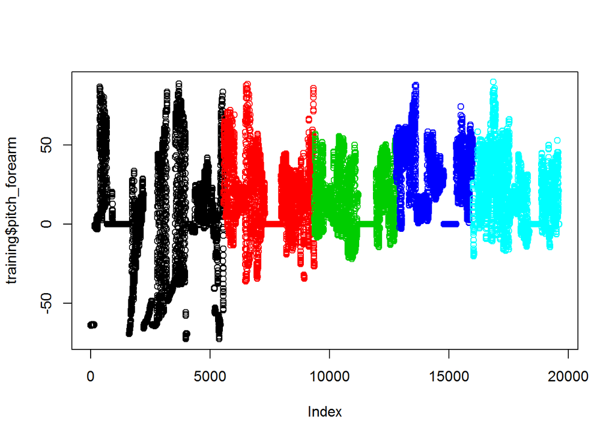

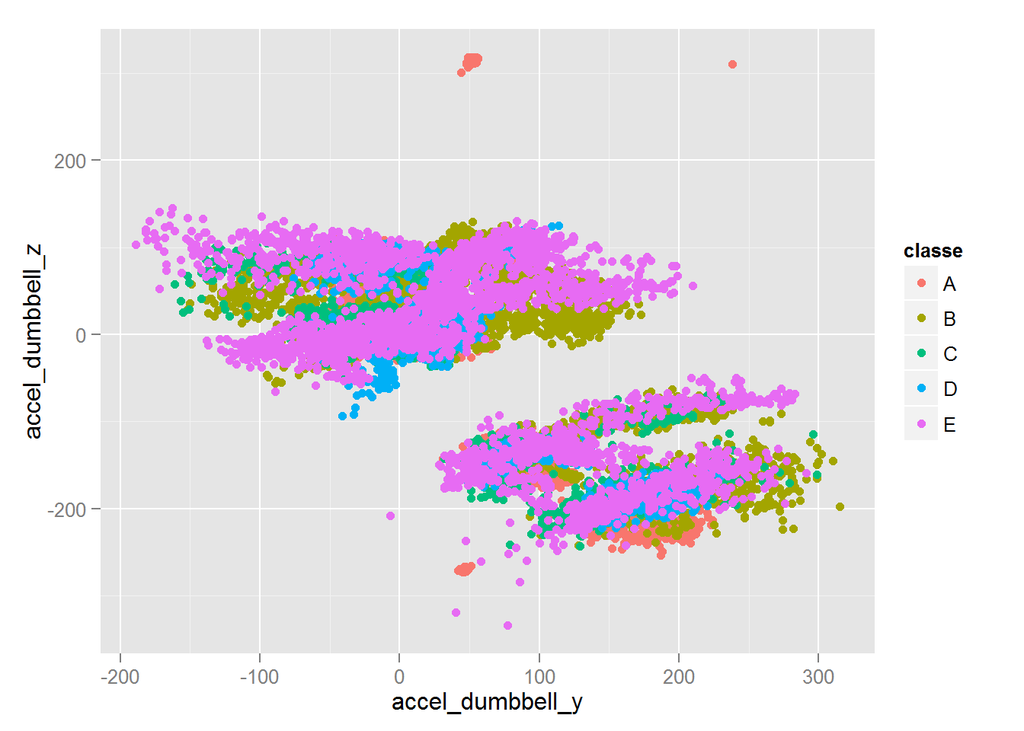

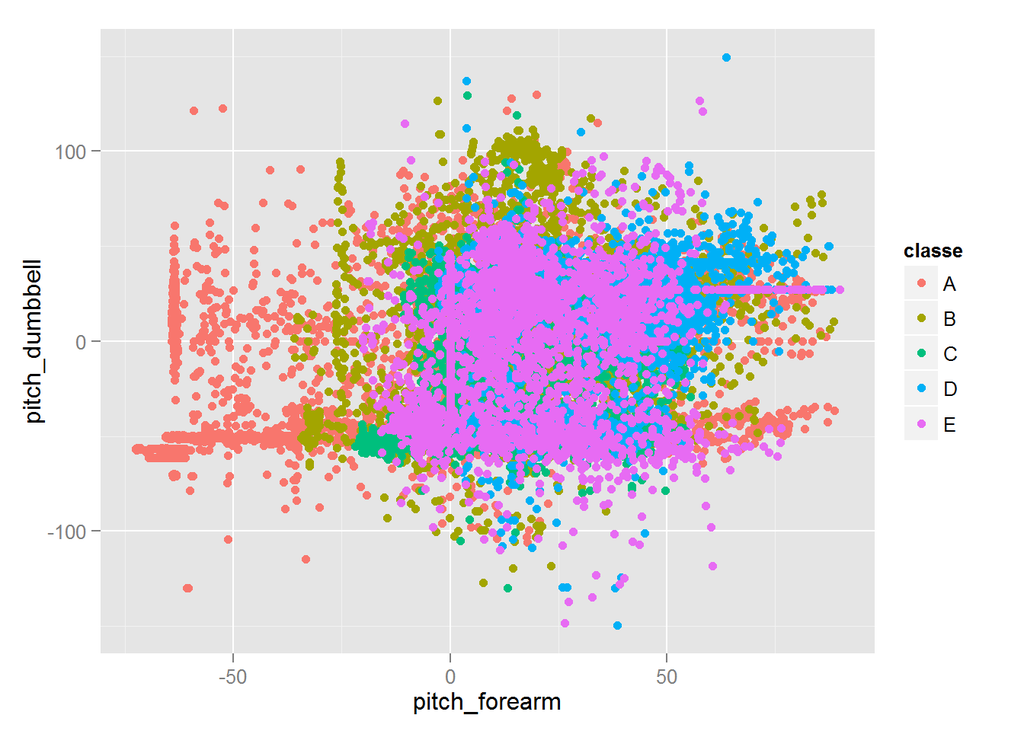

## Cross Validation

As can be observed from these selected plots, there seems to be no discernible pattern through eyeballing. Thus for cross validation purposes, I divided the training set into 75% training and 25% validation using the rule of thumb provided in the lectures.

```r
##cross validation
intrain <- createDataPartition(training[,"classe"], p = .75)[[1]]
train <- training[intrain,]
cv <- training[-intrain,]
```

## Model used for prediction purposes

The model I run is stochastic gradient boosting with trees, since it produces more accurate results. The tradeoff is that the the results may not be as intepretable, though this is not a concern here since the main objective is for prediction purposes for the testing dataset. Another concern is that there may be overfitting of the data. This will be explored further later.

The results are given below.

```r
modelfit <- train(classe ~ ., data=train, method="gbm", distribution="multinomial", verbose=FALSE)
print(modelfit)
```

```
## Stochastic Gradient Boosting
##
## 14718 samples
##    58 predictor
##     5 classes: 'A', 'B', 'C', 'D', 'E'
##
## No pre-processing
## Resampling: Bootstrapped (25 reps)
##
## Summary of sample sizes: 14718, 14718, 14718, 14718, 14718, 14718, ...
##
## Resampling results across tuning parameters:
##
##   interaction.depth  n.trees  Accuracy   Kappa      Accuracy SD
##   1                   50      0.9997412  0.9996725  0.0003666836
##   1                  100      0.9997782  0.9997193  0.0003340228
##   1                  150      0.9997782  0.9997194  0.0003339560
##   2                   50      0.9997707  0.9997098  0.0003354553
##   2                  100      0.9997856  0.9997285  0.0003327694
##   2                  150      0.9997781  0.9997191  0.0003341750
##   3                   50      0.9997857  0.9997288  0.0003194755
##   3                  100      0.9997931  0.9997382  0.0003265805
##   3                  150      0.9997930  0.9997380  0.0003267400
##   Kappa SD
##   0.0004643750
##   0.0004231235
##   0.0004230157
##   0.0004249695
##   0.0004215604
##   0.0004233419
##   0.0004047356
##   0.0004137211
##   0.0004139245
##
## Tuning parameter 'shrinkage' was held constant at a value of 0.1
## Accuracy was used to select the optimal model using  the largest value.
## The final values used for the model were n.trees = 100,
##  interaction.depth = 3 and shrinkage = 0.1.
```

## Accuracy of model on training set

```r
predicttrain <- predict(modelfit,train)
confusionMatrix(train$classe, predicttrain)
```

```
## Confusion Matrix and Statistics
##
##           Reference
## Prediction    A    B    C    D    E
##          A 4185    0    0    0    0
##          B    0 2848    0    0    0
##          C    0    0 2567    0    0
##          D    0    0    0 2412    0
##          E    0    0    0    0 2706
##
## Overall Statistics
##
##                Accuracy : 1
##                  95% CI : (0.9997, 1)
##     No Information Rate : 0.2843
##     P-Value [Acc > NIR] : < 2.2e-16
##
##                   Kappa : 1
##  Mcnemar's Test P-Value : NA
##
## Statistics by Class:
##
##                      Class: A Class: B Class: C Class: D Class: E
## Sensitivity            1.0000   1.0000   1.0000   1.0000   1.0000
## Specificity            1.0000   1.0000   1.0000   1.0000   1.0000
## Pos Pred Value         1.0000   1.0000   1.0000   1.0000   1.0000
## Neg Pred Value         1.0000   1.0000   1.0000   1.0000   1.0000
## Prevalence             0.2843   0.1935   0.1744   0.1639   0.1839
## Detection Rate         0.2843   0.1935   0.1744   0.1639   0.1839
## Detection Prevalence   0.2843   0.1935   0.1744   0.1639   0.1839
## Balanced Accuracy      1.0000   1.0000   1.0000   1.0000   1.0000
```

## Estimation of out of sample error rate on cross validation set

I test the model on the cross-validation set to obtain an estimate of the out of sample error rate.

```r
predictcv <- predict(modelfit, cv)
confusionMatrix(cv$classe, predictcv)
```

```
## Confusion Matrix and Statistics
##
##           Reference
## Prediction    A    B    C    D    E
##          A 1394    1    0    0    0
##          B    0  948    1    0    0
##          C    0    0  854    1    0
##          D    0    0    0  804    0
##          E    0    0    0    0  901
##
## Overall Statistics
##
##                Accuracy : 0.9994
##                  95% CI : (0.9982, 0.9999)
##     No Information Rate : 0.2843
##     P-Value [Acc > NIR] : < 2.2e-16
##
##                   Kappa : 0.9992
##  Mcnemar's Test P-Value : NA
##
## Statistics by Class:
##
##                      Class: A Class: B Class: C Class: D Class: E
## Sensitivity            1.0000   0.9989   0.9988   0.9988   1.0000
## Specificity            0.9997   0.9997   0.9998   1.0000   1.0000
## Pos Pred Value         0.9993   0.9989   0.9988   1.0000   1.0000
## Neg Pred Value         1.0000   0.9997   0.9998   0.9998   1.0000
## Prevalence             0.2843   0.1935   0.1743   0.1642   0.1837
## Detection Rate         0.2843   0.1933   0.1741   0.1639   0.1837
## Detection Prevalence   0.2845   0.1935   0.1743   0.1639   0.1837
## Balanced Accuracy      0.9999   0.9993   0.9993   0.9994   1.0000
```

As before, accuracy appears to be very high since 99.9% of observations were correctly classified. Based on the cross-validation set, I estimate that the out of sample error rate should be about 0.1%.